# Canopy Analysis using Forest Tools

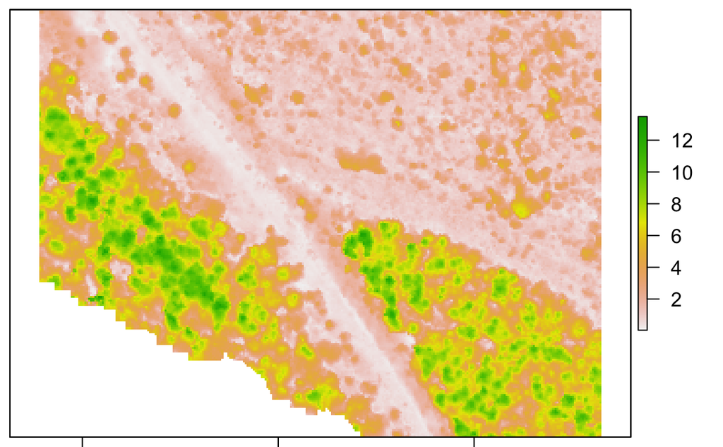

```r
# Install packages - install.packages("ForestTools")
# Load packages
library(ForestTools)
library(raster)

# Load sample canopy height model
data("kootenayCHM")

# remove plot margins(optional)
par(mar = rep(0.5, 4))

# plot CHM (Extra optionale arguments remove labels and tick marks from the plot)
plot(kootenayCHM, xlab = "", ylab = "n", yaxt = 'n')
```

### Detecting treetops

Dominant treetops can be detected using `vwf`

this function implements the variable window filter algorithm developed by Popescu and Wayne. A moving window scans the CHM, and if a given cell is found to be the highest within the window, it is tagged as a treetop. The size of the window itself changes depending on the height of the cell on which it is centered. This is to compensate for the varying crown sizes, with tall trees having wide crowns and vice versa.

Therefore the first step is to determine the function that will define the dynamic window size.. Essentially this cell should take a CHM cell value (i.e height of the canopy above the ground at that location) and return the radius of the search window. Here we will define a simple linear equation, but any funcition with a single input and output will work.

```r
lin <- function(x){x * 0.05 + 0.6}
```

We do not wish for the `vwf` to lag low-lying underbrush or other spurious treetops, and so we also set a minimum height of 2m using the `minHeight` argument. any cell with a lower value will not be tagged as a treetop

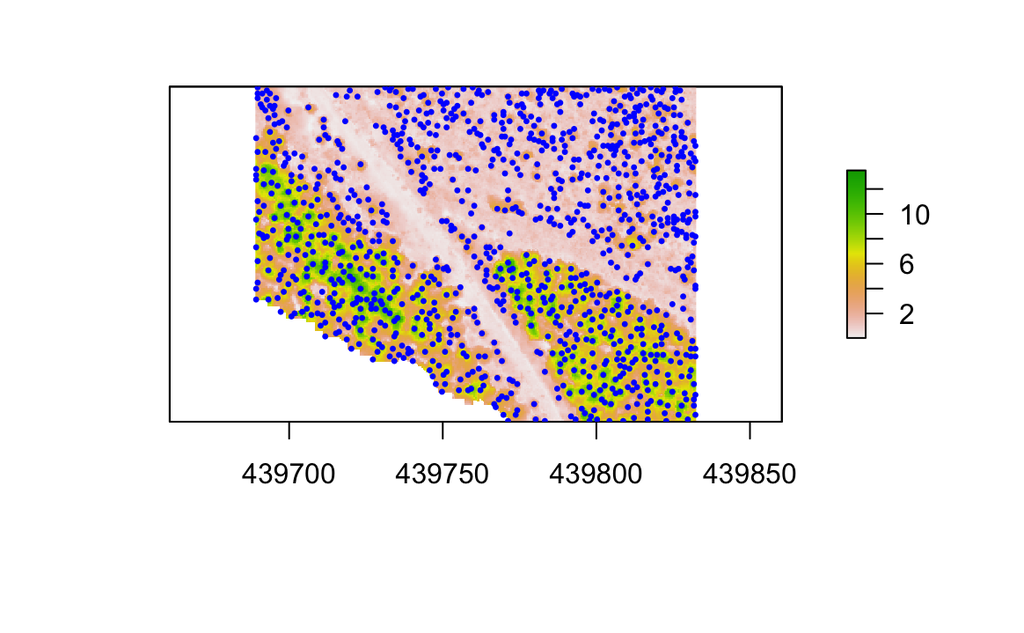

```r
ttops <- vwf(CHM = kootenayCHM, winFun = lin, minHeight = 2)

# Plot these treetops on top of the CHM

plot(kootenayCHM, xlab = "", ylab = "", xat = 'n', yaxt = 'n')

# Add dominant treetops to the plot
plot(ttops, col = "blue", pch = 20, cex = 0.5, add = TRUE)
```

```r
mean(ttops$height)
```

```
[1] 5.404217
```

**Outlining tree crowns**

Canopy height models often represent continuous, dense forests, where tree crowns abut against each other. Outlining discrete crown shapes from this type of forest is often referred to as canopy segmentation, where each crown outline is represented by a segment. Once a set of treetops have been detected from a canopy height model, `mcws` function can be used for this purpose.

The `mcwsz` function implements the watershed algorithm from the imager library. Watershed algorithms are frequently used in topographical analysis to outline drainage basins. Given the morphological similarity between an inverted canopy and a terrain model, this same process can be used to outline the tree crowns. However a potential issue of oversegmentation, whereby branches, bumbs and other spurious treetops are given their own segments. This source of error can be mitigated by using a variant of the algorithm known as marker-controlled segmentation, whereby the watershed algorithm is constrained by a set of markers-in this case treetops.

The `mcws` function also takes a `minHeight` argument, although this value should be lower than that which was assigned to `vwf`. For the latter, `minHeight` defines the lowest expected treetop, whereas for the former it should correspond to the height above ground of the fringes of the lowest trees

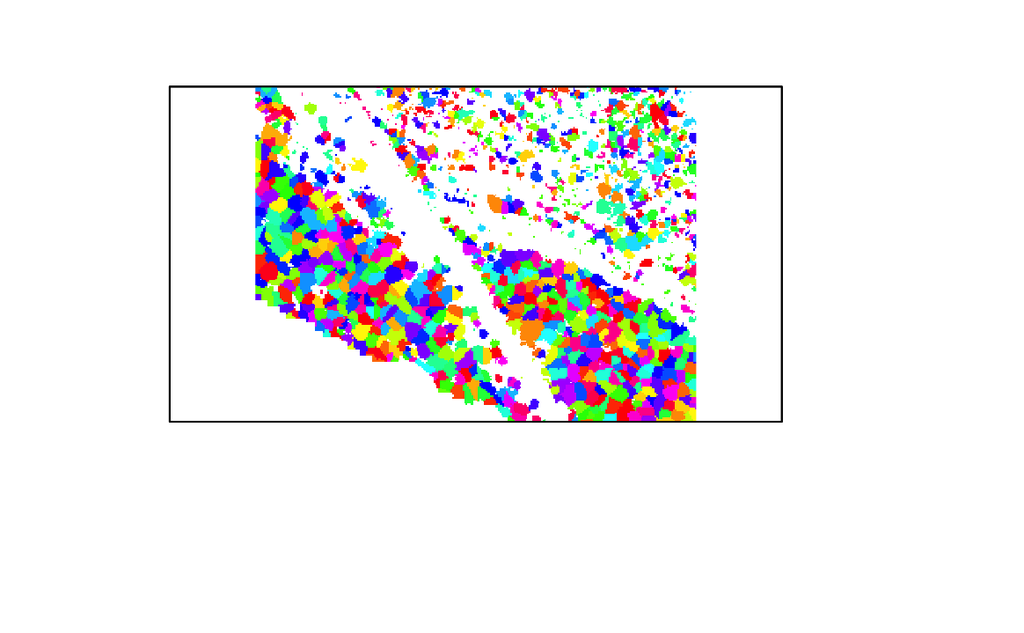

```r
# Create a crown map
crowns <- mcws(treetops = ttops, CHM = kootenayCHM, minHeight = 1.5, verbose = FALSE)

# plot crowns
plot(crowns, col=sample(rainbow(50), length(unique(crowns[])), replace = TRUE), legend = FALSE, xlab = "", ylab = "", xaxt = 'n', yaxt = 'n')
```

By default, `mcws` return a raster, where each crown is given a unique cell value. Depending on the intended purpose of the crown map, it may be preferable to store these outlines as polygons. setting the format to polygons will convert the rasterized crown map to a set of polygons(A spatialPolygonsDataframe)

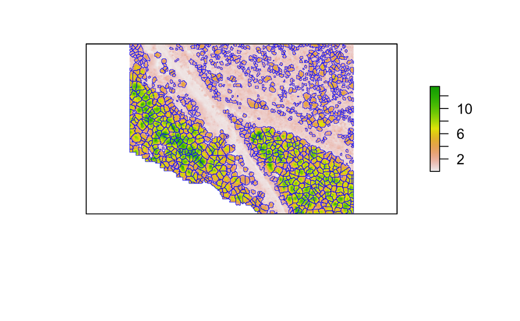

```r
# Create polygon crown map
crownsPoly <- mcws(treetops = ttops, CHM = kootenayCHM, format = "polygons", minHeight = 1.5, verbose = FALSE)

# Plot CHM
plot(kootenayCHM, xlab = "", ylab = "", xaxt='n', yaxt='n')

# Add crown outlines to the point
plot(crownsPoly, border = "blue", lwd = 0.5, add = TRUE)
```

Assuming that each crown has a roughly circular shape, we can use the crown’s area to compute its average circular diameter

```r
crownsPoly[["crownDiameter"]] <- sqrt(crownsPoly[["crownArea"]]/pi) * 2
mean(crownsPoly$crownDiameter)
```

```
[1] 2.882985
```

### Spatial Statistics

|  | Value |
| --- | --- |
| TreeCount | 1077 |

|  | Value |
| --- | --- |
| TreeCount | 1077.000000 |
| crownAreaMean | 7.454271 |
| crownAreaMedian | 6.250000 |
| crownAreaSD | 5.398044 |
| crownAreaMin | 0.250000 |
| crownAreaMax | 53.000000 |
| heightMean | 5.404217 |
| heightMedian | 4.487972 |
| heightSD | 2.969385 |
| heightMin | 2.002042 |

[output cut: 1 more lines]

### Statistics by polygons

The forest tools package includes the boundaries of three cutting blocks that can be overlayed on CHM. Tree counts and height statistcs can be summarizes within these boundaries using the `areas` argument

```r
data("kootenayBlocks")

blockStats <- sp_summarise(ttops, areas = kootenayBlocks, variables = "height")

plot(kootenayCHM, xlab = "", ylab = "", xaxt="n", yaxt="n")
plot(kootenayBlocks, add = TRUE, border = "darkmagenta", lwd = 2)
```

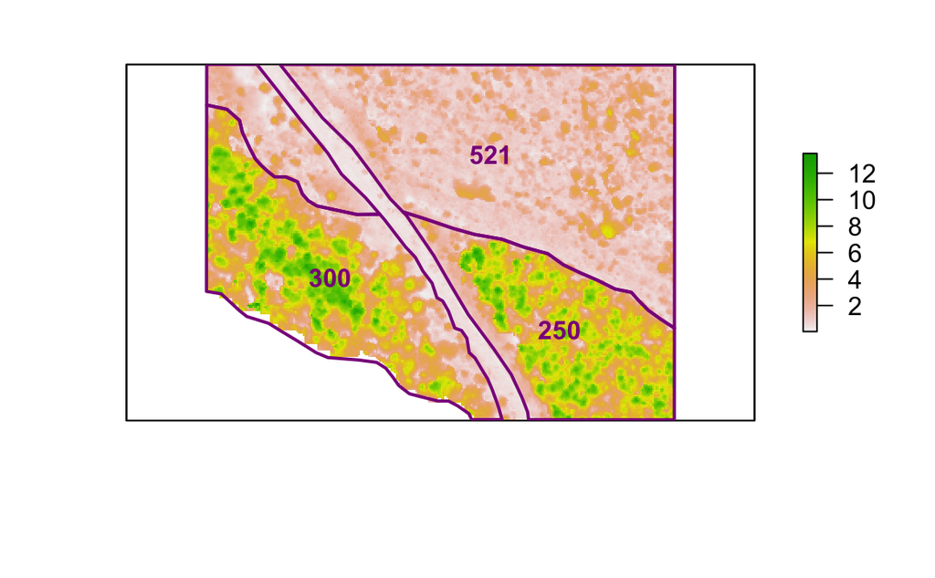

```r
# Add tree counts to the plot
library(rgeos)
text(gCentroid(kootenayBlocks, byid = TRUE), blockStats[["TreeCount"]], col = "darkmagenta", font = 2)
```

```r
blockStats@data
```

|  | BlockID | Shape_Leng | Shape_Area | TreeCount | heightMean | heightMedian | heightSD | heightMin | heightMax |
| --- | --- | --- | --- | --- | --- | --- | --- | --- | --- |
| 0 | 101 | 304.3290 | 3706.389 | 300 | 7.538894 | 7.691572 | 2.587075 | 2.331073 | 13.491207 |
| 1 | 3308 | 508.6240 | 6712.607 | 521 | 3.111031 | 2.771317 | 1.003606 | 2.002042 | 7.125149 |
| 2 | 113 | 239.5202 | 2767.266 | 250 | 7.635933 | 8.180647 | 2.510343 | 2.053920 | 12.583441 |

### Statistics by grid

Instead of defining polygonal areas, the sp_summaries function can also generate counts and statistics in raster format. IN this case, the grid argument should be used instead of areas.

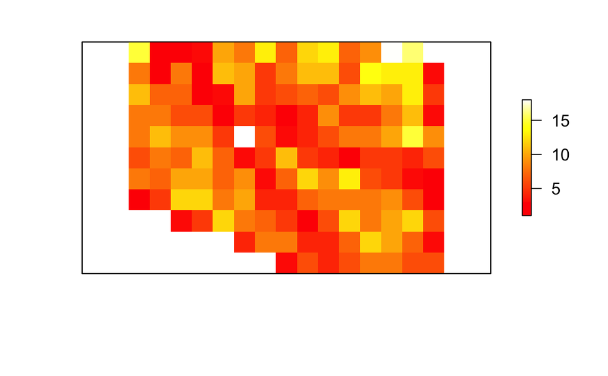

```r
gridCount <- sp_summarise(ttops, grid = 10)

# plot grid
plot(gridCount, col = heat.colors(255), xlab = "", ylab = "", xaxt='n', yaxt = 'n')
```

If, in addition to tree count, tree attribute statistics are computed, the object returned by `sp_summarise` will be a [RasterBrick](https://cran.r-project.org/package=raster/raster.pdf#page=36), i.e.: a multi-layered raster.

```r
names(gridStats)
```

```
[1] "TreeCount"    "heightMean"   "heightMedian" "heightSD"     "heightMin"    "heightMax"
```